# 25 days of chRistmas: an R advent calendaR!

### DAY 18

On the eighteenth day of Christmas…

…you’re going to learn how to create a new data frame. And we’re going to toss some NAs in there to deal with tomorrow!

We’ll be using the data.frame() function from base R. We’ll also be using the rep() function which stands for ‘repeated’.

| type | xmas.magic |
| --- | --- |
| pine | 8 |
| pine | 8 |
| pine | 8 |
| pine | 8 |
| pine | 8 |
| spruce | 6 |
| spruce | 6 |
| spruce | 6 |
| spruce | 6 |
| spruce | 6 |

[output cut: 5 more lines]

Highlight and run tree.dat3 to see your new data.frame!

***Note: NA should not be in quotation marks, otherwise R will not recognize it as missing data, but as a variable you just happen to be referring to as “NA” (e.g. someone’s initials). If you don’t see the NAs, try clicking the little “2” or “Next” in the bottom right of your data, or open tree.dat3 from your Environment.

### DAY 19

On the nineteenth day of Christmas…

…you get to deal with those nasty, annoying NAs that we put into our new data.frame from yesterday tree.dat3.

There are lots of ways you can deal with NAs in a dataset. First I should mention, that if you’re organizing your own data for a project, do not leave blanks in your data file. Instead use “NA” with no spaces or periods.

We’re going to go ahead and just exclude all rows that include NAs. In this simple case, we could just remove all of our maples, but if the NAs were spread across different types of trees, removing the NAs would be easier. So I will show you how to do that.

We’re going to use the na.omit() function:

```r
tree.dat4 <-na.omit(tree.dat3)
```

This creates yet another tree dataset but without missing data.

Here’s a good resource for other things you can do with missing data: https://www.statmethods.net/input/missingdata.html

### DAY 20

On the twentieth day of Christmas…

…you’re going to learn how to do a simple linear regression in R.

First we *should* check assumptions of linear regression, but for the purpose of this calendaR, I’m going to assume you already did that. Here is one resource you can use to find information for checking assumptions: https://www.r-bloggers.com/checking-glm-model-assumptions-in-r/.

To run our simple linear regression, we will use the function lm(). For this you will be using the package, “stats”. If it tells you the function does not exist, it means you need to download this package.

Name your model. Let’s call it tree.lm (for tree linear model). We’re going to test if there is a relationship between tree fragrance and the amount of ‘Christmas magic’ it has. Let’s say our hypothesis is that as tree fragrances increases, the amount of ‘Christmas magic’ is produces also increases. Let’s test that…

```r
tree.lm <-lm(fragrance~xmas.magic, data=tree.dat)
```

Nothing happened right? This is where we use the summary() function to get our results

```r
summary(tree.lm)
```

```
Call:
lm(formula = fragrance ~ xmas.magic, data = tree.dat)

Residuals:
     Min       1Q   Median       3Q      Max
-2.89215 -0.32698  0.04894  0.37296  1.71758

Coefficients:
            Estimate Std. Error t value Pr(>|t|)
(Intercept) -0.11965    0.55477  -0.216    0.831
xmas.magic   1.01620    0.07677  13.237 1.42e-13 ***
---
Signif. codes:  0 ‘***’ 0.001 ‘**’ 0.01 ‘*’ 0.05 ‘.’ 0.1 ‘ ’ 1

Residual standard error: 0.7967 on 28 degrees of freedom
Multiple R-squared:  0.8622,    Adjusted R-squared:  0.8573
F-statistic: 175.2 on 1 and 28 DF,  p-value: 1.424e-13
```

What did you find? Is there a ‘significant’ relationship between the fragrance a tree has and its ‘Christmas magic’? Given that the p-value is close to 0, we can say that it supports our hypothesis.

### DAY 21

On the twenty-first day of Christmas…

…you’re going to plot the results of your simple regression from yesterday!

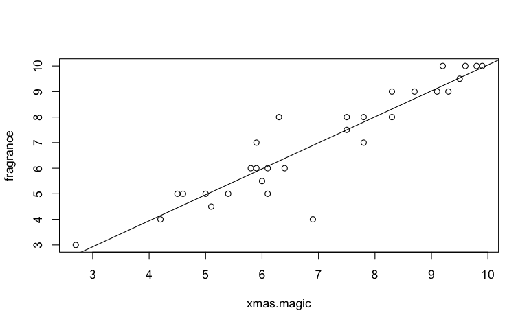

```r
plot(fragrance~xmas.magic, data=tree.dat)
abline(tree.lm)
```

Here we don’t need to specify the type of plot and R will choose for us based on the data we’re provided.

If we want a trend line, we use abline() function:

[figure not shown]

This plots the line on top of our graph based on the results of our linear model.

**NOTE** if you got an error when you tried to run abline(), try running the whole chunk at the same time. Click the green arrow to the right or highlight and run both lines of code.

### DAY 22

On the twenty-second day of Christmas…

…you’re going to customize your scatter plot from yesterday.

There are lots of ways to customize plots, I’m just going to show you a few.

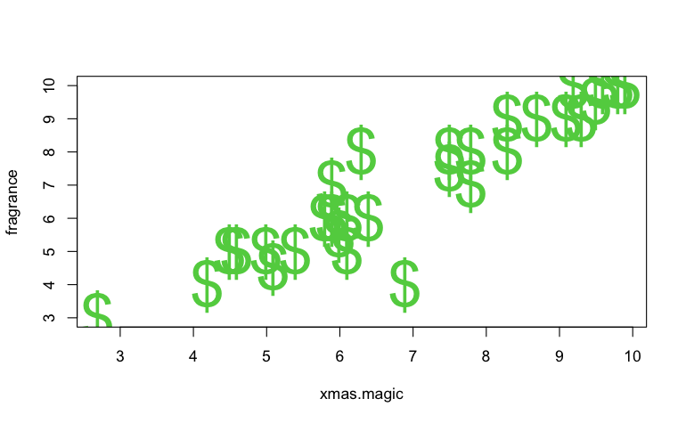

Okay, that’s hideous, let’s make it better….

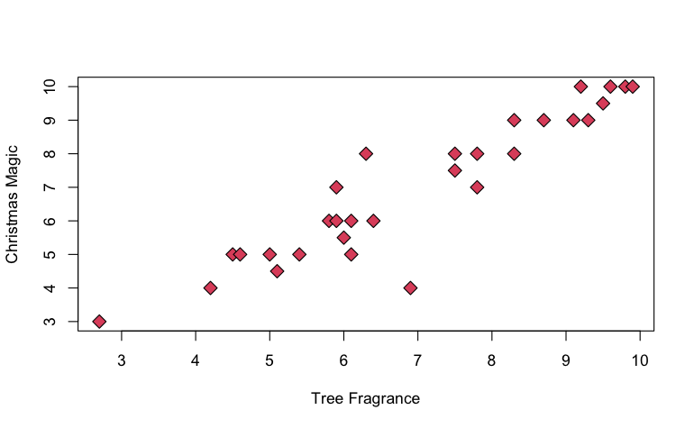

A bit better, and a bit more christmassy!

If you want to add your line back on, do so after you have your plot looking how you want it.

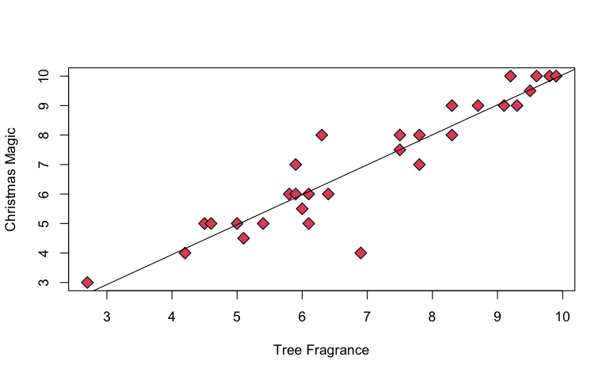

```r
plot(fragrance~xmas.magic, data=tree.dat, cex=1.5, bg=10, pch=23, xlab="Tree Fragrance", ylab="Christmas Magic")
abline(tree.lm)
```

**Got an error?** see note from yesterday.

Just a few options, there are many more you can find online including fonts, x & y axis limits, margins, titles, etc.

col = colour cex = size of points bg = background colour pch = point style xlab = X label ylab = Y label lty = line type (dashed, dotted, etc.) col.lab = label colours

If you want more, check out this resource: https://www.tutorialspoint.com/r/r_scatterplots.htm

### DAY 23

On the twenty-third day of Christmas…

…you’re going to learn some handy tips with ##s.

If you add # in front of text, R will ignore it. This is great for keeping notes right in your R script.

For example:

```r
library(dplyr) #great package for data-wrangling
```

t.test(pines$xmas.magic, spruces$xmas.magic) #ran a t-test to compare mean xmas magic for pines and spruces

If you run that line of code, R will only focus on everything that comes before the #. Keeping good notes will help you later when you’re trying to remember what’s what in your code.

Another fun tip: if you have a lot of code in a single R script, you can add many ### and R will group everything underneath it and you can choose to hide it.

For example:

Linear Models

Try it!

You’ll notice that we’ve been doing this with each day of the calendaR.

### DAY 24

On the twenty-fourth day of Christmas…

…you will learn about some other important R resources!

The R community is full of amazing and talented people. If you can’t figure something out or want to learn something in R, there are many resources.

Here are a couple I use regularly: https://stackoverflow.com https://www.r-bloggers.com

And these cheatsheets are permanent tabs in my browser: https://rstudio.com/wp-content/uploads/2015/02/data-wrangling-cheatsheet.pdf https://rstudio.com/wp-content/uploads/2015/03/ggplot2-cheatsheet.pdf

ggplot2 is a powerful data visualization package. Learn more about it here: https://www.r-graph-gallery.com/ggplot2-package.html

If you want to learn more in R, there are MANY good tutorials online. Here is just one good resource: https://www.statmethods.net/index.html

Most of what I’ve learned in R has been through watching youtube videos, going through online tutorials, and then reaching out to friends or the online community when I get stuck. It can be frustrating, but it is mostly a fun and interesting challenge!

### DAY 25

**MERRY CHRISTMAS!!!**

I hope you enjoyed this little R tutorial advent calendar. You should now have an R script summarizing everything from this tutorial in one place. You can save it to return to later if you’re trying to remember how to do something basic.

Here’s the last code of month. You don’t need to try to understand this code (though hopefully you will recognize some things). Run it to see what it produces! I borrowed this from https://www.r-bloggers.com/make-a-christmas-tree-in-r-with-random-ornamentspresents/.

Make sure you run all the code together at one!

```r
plot(1:10,1:10,xlim=c(-5,5),ylim=c(0,10),type="n",xlab="",ylab="",xaxt="n",yaxt="n")

rect(-1,0,1,2,col="tan3",border="tan4",lwd=3)
```

```r
polygon(c(-5,0,5),c(2,4,2),col="palegreen3",border="palegreen4",lwd=3)
polygon(c(-4,0,4),c(3.5,5.5,3.5),col="palegreen4",border="palegreen3",lwd=3)
```

```r
polygon(c(-3,0,3),c(5,6.5,5),col="palegreen3",border="palegreen4",lwd=3)
polygon(c(-2,0,2),c(6.25,7.5,6.25),col="palegreen4",border="palegreen3",lwd=3)
```

```r
points(x=runif(4,-5,5),y=rep(2,4),col=sample(c("blue","red"),size=4,replace=T),cex=3,pch=19)
points(x=runif(4,-4,4),y=rep(3.5,4),col=sample(c("blue","red"),size=4,replace=T),cex=3,pch=19)
```

```r
points(x=runif(4,-3,3),y=rep(5,4),col=sample(c("blue","red"),size=4,replace=T),cex=3,pch=19)
points(x=runif(4,-2,2),y=rep(6.25,4),col=sample(c("blue","red"),size=4,replace=T),cex=3,pch=19)
```

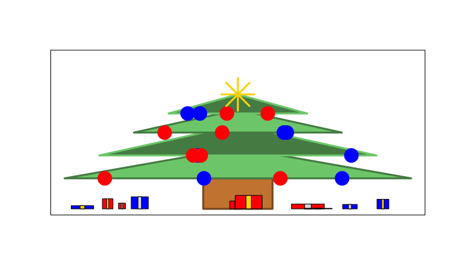

```r
points(0,7.5,pch=8,cex=5,col="gold",lwd=3)

xPres = runif(10,-4.5,4.5)
xWidth = runif(10,0.1,0.5)
xHeight=runif(10,0,1)
for(i in 1:10){
  rect(xPres[i]-xWidth[i],0,xPres[i]+xWidth[i],xHeight[i],col=sample(c("blue","red"),size=1))
  rect(xPres[i]-0.2*xWidth[i],0,xPres[i]+0.2*xWidth[i],xHeight[i],col=sample(c("gold","grey87"),size=1))
}
```

### WANT MORE R?

Check out my ggplot advent calendaR: https://github.com/kiirsti/ggplot_adventcalendaR